# Activity 3: Creating Metadata with `dataspice`

## Prerequisites

Before we begin, ensure you have the following:

- **R and RStudio**: Make sure you have R installed on your system, and RStudio is recommended for an integrated development environment.
- **dataspice package**: Install the `dataspice` package from CRAN by running

```r
install.packages("dataspice")
```

## Step 1: Setting Up Your Project

1. **Create a New R Project**: Organize your work by creating a new RStudio project. This helps in managing your files and maintaining a clean workspace.
2. **Organize Your Data**: Place your dataset(s) in a folder named `data` within your project directory. This standardization aids in seamless metadata creation.

## Step 2: Initializing the Metadata Structure

Use `dataspice` to create the necessary metadata templates:

```r
library(dataspice)
create_spice(dir = "data")
```

This command generates a `metadata` folder inside your `data` directory, containing four CSV files:

- `access.csv`: Details about data accessibility.
- `attributes.csv`: Information about variables in your dataset.
- `biblio.csv`: Dataset-level metadata such as title, description, license, and coverage.
- `creators.csv`: Information about the dataset’s creators.

## Step 3: Populating Metadata Files

You can edit these CSV files manually or use `dataspice`’s interactive functions.

1. **Editing `creators.csv`**:

Launch the interactive editor to add information about the dataset’s creators:

```r
edit_creators()
```

Fill in the required fields and save your changes.

2. **Editing** `access.csv:`

The `access.csv` contains details about **where the data can be accessed**.

Use the interactive editor:

```r
edit_access()
```

3. **Editing `biblio.csv`**:

Provide high-level information about your dataset, including title, description, license, and spatial/temporal coverage.

Use the interactive editor:

```r
edit_biblio()
```

4. **Editing `attributes.csv`**:

Document each variable in your dataset, including its name, description, and data type.

Use the interactive editor:

```r
edit_attributes()
```

Ensure each variable is clearly described to aid future users in understanding the dataset.

**Step 4: Creating a JSON-LD Metadata File**

Now that all our metadata files are complete, we can **compile it all into a structured `dataspice.json` file** in our `data/metadata/` folder.

```r
write_spice()
```

Install and call the required libraries:

```r
install.packages(c("jsonlite", "listviewer", "here", "magrittr", "pkgdown")
```

```r
library(jsonlite)
library(listviewer)
library(here)
library(magrittr)
library(pkgdown)
```

```r
jsonlite::read_json(here::here("data", "metadata", "dataspice.json")) %>%
    listviewer::jsonedit()
```

It will look like this:

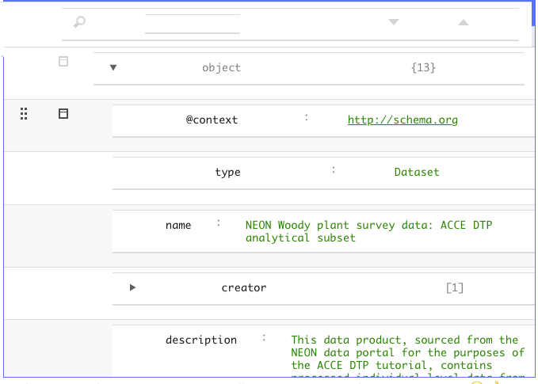

## Step 4: Build README site

Finally, we can **use the `dataspice.json` file** we just created to **produce an informative README web page** to include with our dataset for humans to enjoy! 🤩

We use function **`dataspice::build_site()`** which **creates file `index.html`** in the `docs/` folder of your project (which it creates if it doesn’t already exist).

```r
dataspice::build_site(path = "data/metadata/dataspice.json",
  template_path = system.file("template.html5", package = "dataspice"),
  out_path = "docs/index.html"
)
```

### View the resulting file [here](https://annakrystalli.me/rrresearchACCE20/dataspice/index.html)

Here’s a screen shot!

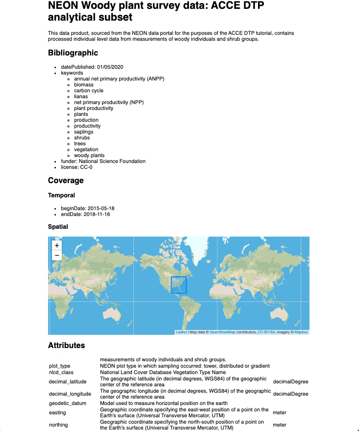

### Example completed metadata files

- [`access.csv`](https://github.com/annakrystalli/rrresearchACCE20/blob/master/data/metadata/access.csv)
- [`attributes.csv`](https://github.com/annakrystalli/rrresearchACCE20/blob/master/data/metadata/attributes.csv)
- [`biblio.csv`](https://github.com/annakrystalli/rrresearchACCE20/blob/master/data/metadata/biblio.csv)
- [`creators.csv`](https://github.com/annakrystalli/rrresearchACCE20/blob/master/data/data/metadata/creators.csv)